# Creating figures

This package offers a workflow for creating standardized figures for time-values data, such as time-concentration profiles, goodness-of-fit plots, etc. The integral part of these workflows are the objects of the class `DataMapping`. A `DataMapping` organizes the objects of the class `XYData` (see Data handling for more information) into groups and maps simulation results to observed data.

## `DataMapping` overview

The first step in organizing the data in a `DataMapping` object and creating figures is the creation of an empty `DataMapping` object.

```r
dataMapping <- DataMapping$new()
print(dataMapping)
```

```
#> DataMapping:
#>   Plot type: IndividualProfile
#>   Population quantiles: 0.050.50.95
#>   labels:
#>   X limits: 00
#>   Y limits: 00
#>   X label
#>   Y label
#>   X unit
#>   Y unit
#>   Title:
#>   Log axes:
```

In the next step, the mapping is populated with xy-values series that can be organized into groups.

### Plotting observed data

Create a data configuration that describes where to find data and which sheets to load and load the data:

```r
dataConfiguration <- DataConfiguration$new(dataFolder = file.path(getwd(), "..", "tests", "data"),
                                    dataFile = "CompiledDataSet.xlsx",
                                    compoundPropertiesFile = "Compound_Properties.xlsx",
                                    dataSheets = c("Stevens_2012_placebo"))
  observedData <- readOSPSTimeValues(dataConfiguration)
```

Add loaded data to `DataMapping`

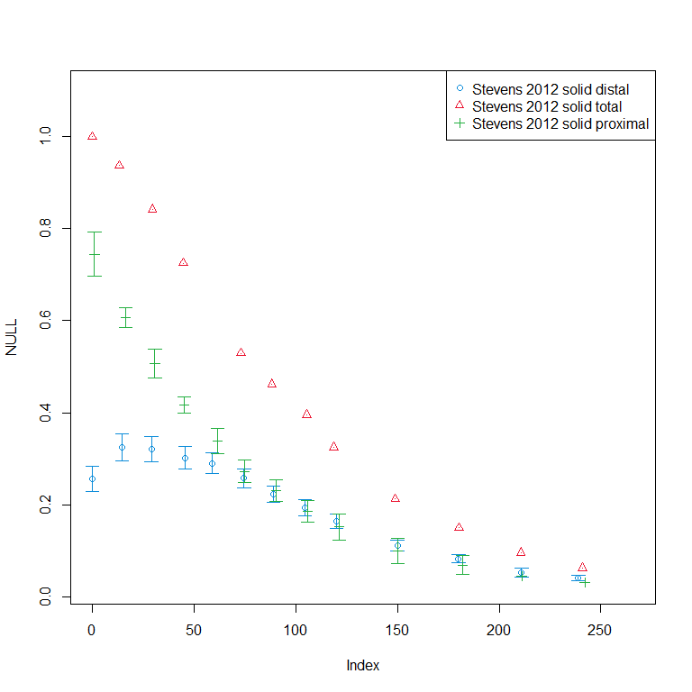

```r
dataMapping <- DataMapping$new()

  dataMapping$addOSPSTimeValues(
    list(observedData$Stevens_2012_placebo$Placebo_distal,
         observedData$Stevens_2012_placebo$Placebo_proximal,
         observedData$Stevens_2012_placebo$Placebo_total),
    groups =     list("Stevens 2012 solid distal",
                      "Stevens 2012 solid proximal",
                      "Stevens 2012 solid total"
    )
  )

  dataMapping$plot()
```

!!! It is not possible to change the labels of data in the legend after the data have been added to the mapping because the data are references in the mapping by their label. Changing the label of a `XYData`-object will lead to the problem that it will not be found by `DataMapping` any more. If required, a method of `DataMapping` must be implemented `setLabel(oldLabel, newLabel)`. It will change the label of the `XYData`-object but also the corresponding name in the list of `DataMapping`. Check should be performed that a new label is not used already. Not feasable to implement before switching to TLF.

It is possible to change the axis labels and figure title.

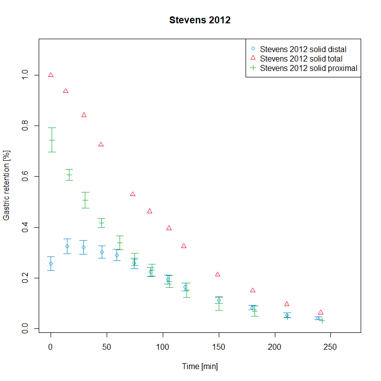

```r
  dataMapping$xLab <- "Time [min]"
  dataMapping$yLab <- "Gastric retention [%]"
  dataMapping$title <- "Stevens 2012"

  dataMapping$plot()
```

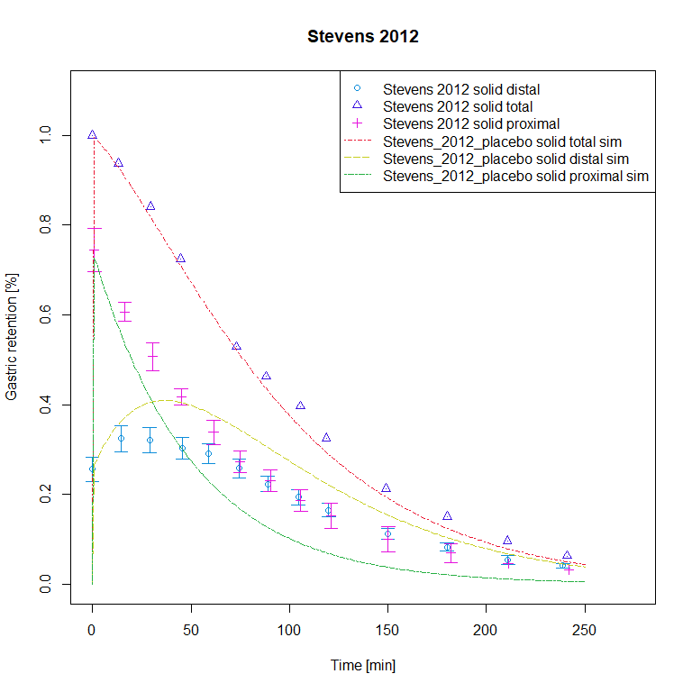

```r
sim <- loadSimulation(file.path(getwd(), "..", "tests", "data", "Stevens_2012_placebo_indiv_results.pkml"))
simResults <- importResultsFromCSV(simulation = sim, filePaths = file.path(getwd(), "..", "tests", "data", "Stevens_2012_placebo_indiv_results.csv"))
outputValues <- getOutputValues(simulationResults = simResults,
                                quantitiesOrPaths = list("Organism|Lumen|Stomach|Metformin|Gastric retention",
                 "Organism|Lumen|Stomach|Metformin|Gastric retention distal",
                 "Organism|Lumen|Stomach|Metformin|Gastric retention proximal"))

  dataMapping$addModelOutputs(
    paths = list("Organism|Lumen|Stomach|Metformin|Gastric retention",
                 "Organism|Lumen|Stomach|Metformin|Gastric retention distal",
                 "Organism|Lumen|Stomach|Metformin|Gastric retention proximal"),
    outputValues = outputValues,
    simulation = sim,
    list("Stevens_2012_placebo solid total sim",
         "Stevens_2012_placebo solid distal sim",
         "Stevens_2012_placebo solid proximal sim"
    )
  )

  dataMapping$plot()
```

Add simulation results to the mapping, assigning to the correct groups. Simulation results are now have same colors as observed data of the same group. As the labels of the assigned data sets are equal as the ones assigned in the previous steps, the previous sets are overwritten.

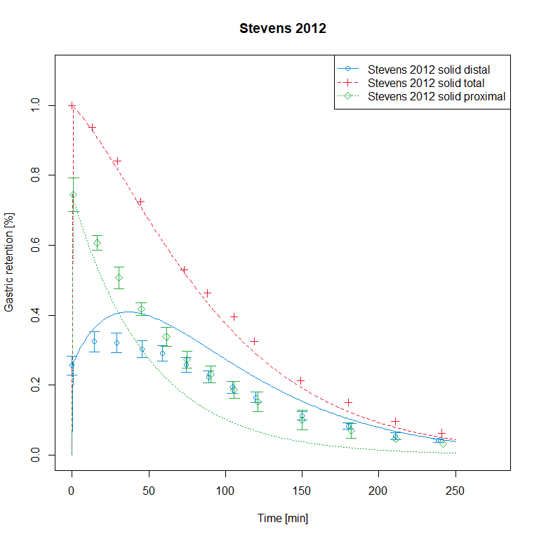

```r
  dataMapping$addModelOutputs(
    paths = list("Organism|Lumen|Stomach|Metformin|Gastric retention",
                 "Organism|Lumen|Stomach|Metformin|Gastric retention distal",
                 "Organism|Lumen|Stomach|Metformin|Gastric retention proximal"),
    outputValues = outputValues,
    simulation = sim,
    list("Stevens_2012_placebo solid total sim",
         "Stevens_2012_placebo solid distal sim",
         "Stevens_2012_placebo solid proximal sim"
    ),
    groups =     list("Stevens 2012 solid total",
                      "Stevens 2012 solid distal",
                      "Stevens 2012 solid proximal"
    )
  )

  dataMapping$plot()
```

It is possible to change the units of the axis. Mind that axis labels are not automatically adjusted. It could be implemented that the default label (if not set by user) is always `Dimension [unit]`

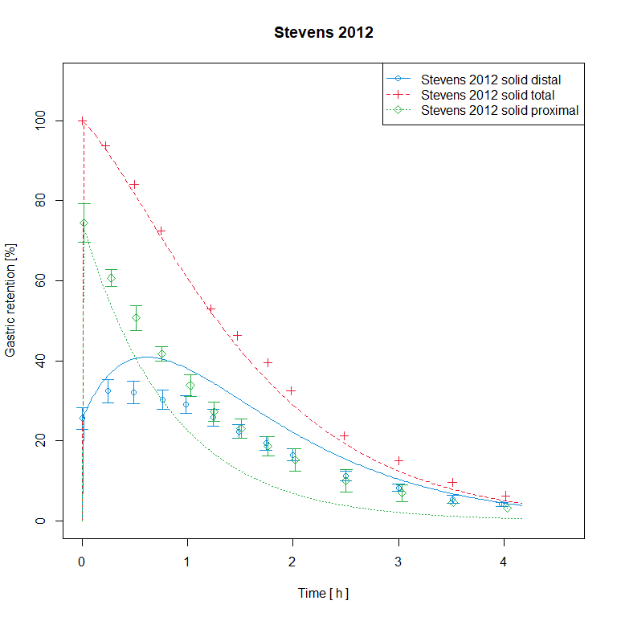

```r
dataMapping$xUnit <- "h"
dataMapping$yUnit <- "%"
dataMapping$xLab <- paste(dataMapping$xDimension, "[", dataMapping$xUnit, "]")

dataMapping$plot()
```

Create a clone of the data mapping and change its plot type to “predicted vs observed”.